# Cyclistic bike share analysis

Nawid Ahmad Noori

2/3/2022

[figure not shown]

Company logo

## Introduction

This analysis case study is part of Google data analytics Professional certificate.I used bike-sharing company data to analyze user behavior, find similarities and differences, determine trends, and provide recommendations on how these insights can help the marketing team to create a campaign that would convert one type of users into another.

## Scenario

Cyclistic is a bike-share company in Chicago,which have two types of customers,casual(pay for each ride) andmembers(pay yearly subscription), The director of marketing believes the company’s future success depends on maximizing the number of member customers. Therefore, we wants to understand how casual riders and member riders use Cyclistic bikes differently. From these insights, marketing team will design a new marketing strategy to convert casual riders into annual members.

## Stakeholders

●Cyclistic: A bike-share program that features more than 5,800 bicycles and 600 docking stations.

●Lily Moreno: The director of marketing and your manager. Moreno is responsible for the development of campaigns and initiatives to promote the bike-share program. These may include email, social media, and other channels.

●Cyclistic marketing analytics team: A team of data analysts who are responsible for collecting, analyzing, and reporting data that helps guide Cyclistic marketing strategy.

●Cyclistic Executive Team : Detail-oriented executive team that will decide whether to approve the recommended marketing program

## Phase 1: ASK

### Identify the business task

The key business task in this case study is to discover how casual riders and Cyclistic members use their rental bikes differently. Both the Director of Marketing as well as finance analysts have concluded that member customers are more profitable.

Therefore, the results of this analysis will be used to design a new marketing strategy to convert casual riders to annual members.

### Consider key stakeholders

Key stakeholders include: Cyclistic executive team, Director of Marketing (Lily Moreno), Marketing Analytics team.

## Phase 2 : Prepare

### Data source

User data from the past 12 months, January 2021 - December 2021 are available in the company cloud storage. Each data set is consists of 13 columns with a various number of records depending on each month’s rides, data sets are in csv format and details every ride logged by Cyclistic customers. This data has been made publicly available via license by Motivate International Inc. and the city of Chicago available here. All user’s personal data has been scrubbed for privacy.

### Determine the credibility of the data and bias

Due to the fact that this is a case study using public data, we are going to assume the data is credible.

### Download data and store it appropriately

Data has been downloaded from the company cloud storage. Local copies have been stored securely on Data folder in the folder of the Rstudio project

## Phase 3 : Process

### Choose your tools

For this analysis, we will be using R for it’s easy statistical analysis tools and data visualizations.

### Explore the Data

#### view head of data frame

```r
head(Data)
```

```
##            ride_id rideable_type          started_at            ended_at
## 1 E19E6F1B8D4C42ED electric_bike 2021-01-23 16:14:19 2021-01-23 16:24:44
## 2 DC88F20C2C55F27F electric_bike 2021-01-27 18:43:08 2021-01-27 18:47:12
## 3 EC45C94683FE3F27 electric_bike 2021-01-21 22:35:54 2021-01-21 22:37:14
## 4 4FA453A75AE377DB electric_bike 2021-01-07 13:31:13 2021-01-07 13:42:55
## 5 BE5E8EB4E7263A0B electric_bike 2021-01-23 02:24:02 2021-01-23 02:24:45
## 6 5D8969F88C773979 electric_bike 2021-01-09 14:24:07 2021-01-09 15:17:54
##           start_station_name start_station_id end_station_name end_station_id
## 1 California Ave & Cortez St            17660
## 2 California Ave & Cortez St            17660
## 3 California Ave & Cortez St            17660
## 4 California Ave & Cortez St            17660
## 5 California Ave & Cortez St            17660
## 6 California Ave & Cortez St            17660
##   start_lat start_lng end_lat end_lng member_casual
## 1  41.90034 -87.69674   41.89  -87.72        member
## 2  41.90033 -87.69671   41.90  -87.69        member
## 3  41.90031 -87.69664   41.90  -87.70        member
## 4  41.90040 -87.69666   41.92  -87.69        member
## 5  41.90033 -87.69670   41.90  -87.70        casual
## 6  41.90041 -87.69676   41.94  -87.71        casual
```

#### view the detailed description and structure of data frame

```r
str(Data)
```

```
## 'data.frame':    5595063 obs. of  13 variables:
##  $ ride_id           : chr  "E19E6F1B8D4C42ED" "DC88F20C2C55F27F" "EC45C94683FE3F27" "4FA453A75AE377DB" ...
##  $ rideable_type     : chr  "electric_bike" "electric_bike" "electric_bike" "electric_bike" ...
##  $ started_at        : chr  "2021-01-23 16:14:19" "2021-01-27 18:43:08" "2021-01-21 22:35:54" "2021-01-07 13:31:13" ...
##  $ ended_at          : chr  "2021-01-23 16:24:44" "2021-01-27 18:47:12" "2021-01-21 22:37:14" "2021-01-07 13:42:55" ...
##  $ start_station_name: chr  "California Ave & Cortez St" "California Ave & Cortez St" "California Ave & Cortez St" "California Ave & Cortez St" ...
##  $ start_station_id  : chr  "17660" "17660" "17660" "17660" ...
##  $ end_station_name  : chr  "" "" "" "" ...
##  $ end_station_id    : chr  "" "" "" "" ...
##  $ start_lat         : num  41.9 41.9 41.9 41.9 41.9 ...
##  $ start_lng         : num  -87.7 -87.7 -87.7 -87.7 -87.7 ...
##  $ end_lat           : num  41.9 41.9 41.9 41.9 41.9 ...
##  $ end_lng           : num  -87.7 -87.7 -87.7 -87.7 -87.7 ...
##  $ member_casual     : chr  "member" "member" "member" "member" ...
```

#### View data labels

```r
colnames(Data)
```

```
##  [1] "ride_id"            "rideable_type"      "started_at"
##  [4] "ended_at"           "start_station_name" "start_station_id"
##  [7] "end_station_name"   "end_station_id"     "start_lat"
## [10] "start_lng"          "end_lat"            "end_lng"
## [13] "member_casual"
```

#### View summary of dataframe

```r
summary(Data)
```

```
##    ride_id          rideable_type       started_at          ended_at
##  Length:5595063     Length:5595063     Length:5595063     Length:5595063
##  Class :character   Class :character   Class :character   Class :character
##  Mode  :character   Mode  :character   Mode  :character   Mode  :character
##
##
##
##
##  start_station_name start_station_id   end_station_name   end_station_id
##  Length:5595063     Length:5595063     Length:5595063     Length:5595063
##  Class :character   Class :character   Class :character   Class :character
##  Mode  :character   Mode  :character   Mode  :character   Mode  :character
##
##
##
##
##    start_lat       start_lng         end_lat         end_lng
##  Min.   :41.64   Min.   :-87.84   Min.   :41.39   Min.   :-88.97
##  1st Qu.:41.88   1st Qu.:-87.66   1st Qu.:41.88   1st Qu.:-87.66
##  Median :41.90   Median :-87.64   Median :41.90   Median :-87.64
##  Mean   :41.90   Mean   :-87.65   Mean   :41.90   Mean   :-87.65
##  3rd Qu.:41.93   3rd Qu.:-87.63   3rd Qu.:41.93   3rd Qu.:-87.63
##  Max.   :42.07   Max.   :-87.52   Max.   :42.17   Max.   :-87.49
##                                   NA's   :4771    NA's   :4771
##  member_casual
##  Length:5595063
##  Class :character
##  Mode  :character
##
##
##
##
```

### Data Cleaning and transformation

Further inspection of the files showed that there are multiple null values, incorrect data type and mislabeled columns

#### Remove null values and duplicate records

The code chunk below will remove null values from key columns

```r
Data <-  Data[!(is.na(Data$rideable_type) | Data$rideable_type=="" | Data$member_casual=="N/A"), ]
Data <-  Data[!(is.na(Data$started_at) | Data$started_at=="" | Data$member_casual== "N/A"), ]
Data <-  Data[!(is.na(Data$ended_at) | Data$ended_at=="" | Data$member_casual== "N/A"), ]
Data <-  Data[!(is.na(Data$start_station_name) | Data$start_station_name=="" | Data$start_station_name== "N/A"), ]
Data <-  Data[!(is.na(Data$end_station_name) | Data$end_station_name=="" | Data$end_station_name== "N/A"), ]
Data <-  Data[!(is.na(Data$member_casual) | Data$member_casual=="" | Data$member_casual== "N/A"), ]
Data<- filter(Data,Data$ride_id !="ride_id") # remove multiple headers
Data <- Data %>% distinct(ride_id, .keep_all= TRUE) # remove duplicate records
```

#### Convert mismatched data types

```r
Data[['started_at']] <- strptime(Data[['started_at']],format = "%Y-%m-%d %H:%M:%S")
Data[['ended_at']] <- strptime(Data[['ended_at']],format = "%Y-%m-%d %H:%M:%S")
```

#### Add the calculated fields

the code chunk below will add required calculated columns for analysis

```r
#add the route column by combining the start and end station names
Data <- mutate(Data,route = paste(Data$start_station_name,"-",Data$end_station_name,sep = ""))
#add the date column
Data$date <- as.Date(Data$started_at)
#add the month column
Data$month <- format(as.Date(Data$started_at), "%b_%y")
#add the season column
Data$season <- format(as.Date(Data$date), "%b")
Data["season"][Data["season"] == "Mar" | Data["season"] == "Apr" | Data["season"] == "May"] <- "Spring"
Data["season"][Data["season"] == "Jun" | Data["season"] == "Jul" | Data["season"] == "Aug"] <- "Summer"
Data["season"][Data["season"] == "Sep" | Data["season"] == "Oct" | Data["season"] == "Nov"] <- "Autumn"
Data["season"][Data["season"] == "Dec" | Data["season"] == "Jan" | Data["season"] == "Feb"] <- "Winter"
#add the day of week column
Data <- mutate(Data,day_of_week = weekdays(Data$started_at))
#add the time column
Data <- mutate(Data,time = format(Data$started_at,format = "%H"))
Data$time <- paste(Data$time,":00",sep = "")
#add the ride length column
Data <- mutate(Data,ride_length = (Data$ended_at - Data$started_at)/60)
Data$ride_length <- as.integer(Data$ride_length)
#add type of day column
Data <- mutate(Data,type_of_day = day_of_week)
Data["type_of_day"][Data["type_of_day"] == "Saturday" | Data["type_of_day"] == "Sunday"] <- "Weekend"
Data["type_of_day"][Data["type_of_day"] == "Monday" | Data["type_of_day"] == "Tuesday" | Data["type_of_day"] == "Wednesday" | Data["type_of_day"] == "Thursday" | Data["type_of_day"] == "Friday"] <- "Workday"
```

#### Rename misleading variable labels

the code chunk below will rename the two columns names and lowercase all labels

```r
Data <- Data %>% rename(customer_type = member_casual)
Data <- Data %>% rename(Bike_type = rideable_type)
Data <- rename_with(Data,tolower)
```

#### Remove the outliers

Lily Moreno has confirmed that records with ride length less then 5 minutes and grather than 1440 minutes are outliers, the code chunk below will remove the outliers

```r
Data <- filter(Data,ride_length >= 5 & ride_length <= 1440)
```

## Phase 4 : Analyze

Find patterns and relationships in data to explore the differences and similarities between the member and casual riders

### Organize data

the code chunk below will organize the data into meaning full order

```r
Data$day_of_week <- ordered(Data$day_of_week, levels=c("Monday", "Tuesday", "Wednesday", "Thursday", "Friday", "Saturday", "Sunday"))
Data$month <- ordered(Data$month, levels=c("Jan_21", "Feb_21", "Mar_21", "Apr_21",  "May_21", "Jun_21","Jul_21", "Aug_21", "Sep_21", "Oct_21","Nov_21", "Dec_21"))
Data$season <- ordered(Data$season, levels=c("Spring","Summer","Autumn","Winter"))
```

#### Get backup of data and remove unnecessary columns

```r
#get a backup of data
#write.csv(Data,"Data/backup.csv",row.names = FALSE)

##remove unnecessary columns
Data <- Data %>% select(-ride_id,-started_at,-ended_at,-start_station_id,-end_station_id)
```

### Look at the specifics of what the data shows

#### summarize the ride length by customer type

```r
Data%>% group_by(customer_type) %>% summarise(total_ride_length = n(),average_ride_length=mean(ride_length),minimum_ride_length=min(ride_length),maximum_ride_length=max(ride_length))
```

```
## # A tibble: 2 x 5
##   customer_type total_ride_length average_ride_length minimum_ride_length
##   <chr>                     <int>               <dbl>               <int>
## 1 casual                  1896525                29.7                   5
## 2 member                  2036093                15.1                   5
## # ... with 1 more variable: maximum_ride_length <int>
```

#### summarize the ride length by customer type and weekday

```r
Data%>% group_by(day_of_week,customer_type) %>% summarise(total_ride_length = n(),average_ride_length=mean(ride_length),minimum_ride_length=min(ride_length),maximum_ride_length=max(ride_length))
```

```
## # A tibble: 14 x 6
## # Groups:   day_of_week [7]
##    day_of_week customer_type total_ride_length average_ride_le~ minimum_ride_le~
##    <ord>       <chr>                     <int>            <dbl>            <int>
##  1 Monday      casual                   210857             30.4                5
##  2 Monday      member                   273246             14.8                5
##  3 Tuesday     casual                   196126             27.5                5
##  4 Tuesday     member                   306573             14.3                5
##  5 Wednesday   casual                   198875             25.9                5
##  6 Wednesday   member                   315754             14.3                5
##  7 Thursday    casual                   204258             25.6                5
##  8 Thursday    member                   295274             14.3                5
##  9 Friday      casual                   267595             27.6                5
## 10 Friday      member                   291686             14.7                5
## 11 Saturday    casual                   439711             31.7                5
## 12 Saturday    member                   296183             16.7                5
## 13 Sunday      casual                   379103             33.8                5
## 14 Sunday      member                   257377             17.2                5
## # ... with 1 more variable: maximum_ride_length <int>
```

#### summarize number of rides by customer type and type of day

```r
Data%>% group_by(type_of_day,customer_type) %>% summarise(count = n())
```

```
## # A tibble: 4 x 3
## # Groups:   type_of_day [2]
##   type_of_day customer_type   count
##   <chr>       <chr>           <int>
## 1 Weekend     casual         818814
## 2 Weekend     member         553560
## 3 Workday     casual        1077711
## 4 Workday     member        1482533
```

#### summarize number of rides by customer type and bike type

```r
Data%>% group_by(bike_type,customer_type) %>% summarise(count = n())
```

```
## # A tibble: 5 x 3
## # Groups:   bike_type [3]
##   bike_type     customer_type   count
##   <chr>         <chr>           <int>
## 1 classic_bike  casual        1168905
## 2 classic_bike  member        1598937
## 3 docked_bike   casual         302797
## 4 electric_bike casual         424823
## 5 electric_bike member         437156
```

#### summarize number of rides by customer type and month

```r
Data%>% group_by(month,customer_type) %>% summarise(count = n())
```

```
## # A tibble: 24 x 3
## # Groups:   month [12]
##    month  customer_type  count
##    <ord>  <chr>          <int>
##  1 Jan_21 casual         13154
##  2 Jan_21 member         53680
##  3 Feb_21 casual          7967
##  4 Feb_21 member         28697
##  5 Mar_21 casual         70679
##  6 Mar_21 member        105473
##  7 Apr_21 casual        112625
##  8 Apr_21 member        146068
##  9 May_21 casual        203393
## 10 May_21 member        193101
## # ... with 14 more rows
```

#### summarize number of rides by customer type and time

```r
Data%>% group_by(time,customer_type) %>% summarise(count = n())
```

```
## # A tibble: 48 x 3
## # Groups:   time [24]
##    time  customer_type count
##    <chr> <chr>         <int>
##  1 00:00 casual        38539
##  2 00:00 member        19584
##  3 01:00 casual        27924
##  4 01:00 member        12844
##  5 02:00 casual        17646
##  6 02:00 member         7006
##  7 03:00 casual         9222
##  8 03:00 member         3863
##  9 04:00 casual         5909
## 10 04:00 member         4302
## # ... with 38 more rows
```

```r
Data%>% group_by(start_station_name,customer_type) %>% summarise(count = n()) %>% top_n(5)
```

```
## # A tibble: 1,642 x 3
## # Groups:   start_station_name [841]
##    start_station_name         customer_type count
##    <chr>                      <chr>         <int>
##  1 2112 W Peterson Ave        casual          326
##  2 2112 W Peterson Ave        member          483
##  3 351                        casual            1
##  4 63rd St Beach              casual         1363
##  5 63rd St Beach              member          545
##  6 900 W Harrison St          casual         2250
##  7 900 W Harrison St          member         4135
##  8 Aberdeen St & Jackson Blvd casual         3069
##  9 Aberdeen St & Jackson Blvd member         6351
## 10 Aberdeen St & Monroe St    casual         3585
## # ... with 1,632 more rows
```

```r
rbind((Data %>%group_by(route,customer_type)%>%filter(customer_type == "casual")%>% summarise(total = n()) %>% top_n(5)),(Data %>%group_by(route,customer_type)%>%filter(customer_type == "member")%>% summarise(total = n()) %>% top_n(5)))
```

```
## # A tibble: 246,515 x 3
## # Groups:   route [152,793]
##    route                                                     customer_type total
##    <chr>                                                     <chr>         <int>
##  1 2112 W Peterson Ave-2112 W Peterson Ave                   casual           23
##  2 2112 W Peterson Ave-Ashland Ave & Division St             casual            1
##  3 2112 W Peterson Ave-Ashland Ave & Wrightwood Ave          casual            1
##  4 2112 W Peterson Ave-Broadway & Argyle St                  casual            2
##  5 2112 W Peterson Ave-Broadway & Berwyn Ave                 casual            3
##  6 2112 W Peterson Ave-Broadway & Granville Ave              casual            8
##  7 2112 W Peterson Ave-Broadway & Ridge Ave                  casual            8
##  8 2112 W Peterson Ave-Broadway & Sheridan Rd                casual            2
##  9 2112 W Peterson Ave-Broadway & Thorndale Ave              casual            8
## 10 2112 W Peterson Ave-Broadway & Wilson - Truman College V~ casual            3
## # ... with 246,505 more rows
```

### Data findings with visualizations

#### Number of Rides per customer type

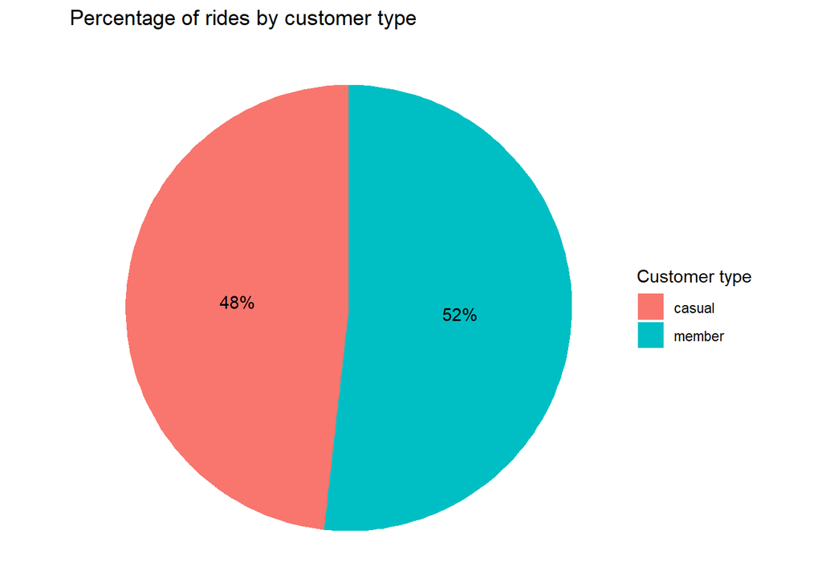

```r
Data %>% group_by(customer_type) %>%summarise(total = (n()/nrow(Data))*100) %>% ggplot(aes(x="", y=total, fill=customer_type))+geom_bar(width = 1, stat = "identity")+coord_polar("y", start=0) + geom_text(aes(label = paste0(round(total), "%")), position = position_stack(vjust = 0.5)) + labs(x = NULL, y = NULL, title = "Percentage of rides by customer type",fill="Customer type") + theme_void()
```

The above visual shows that the members are more renting bikes

#### Average ride length by customer type

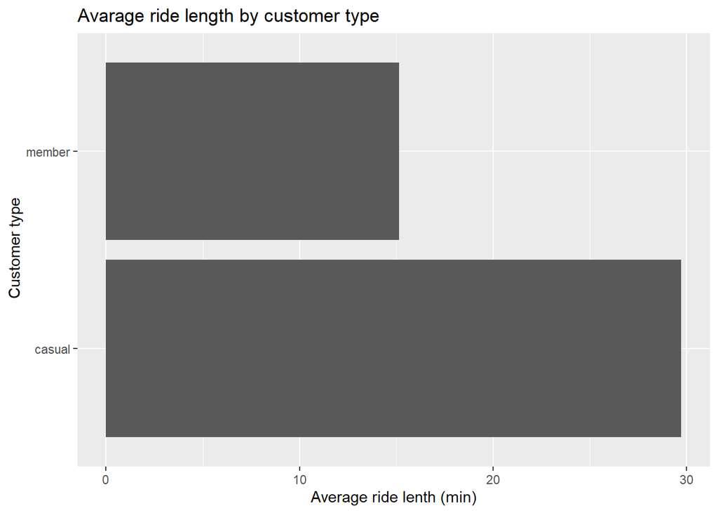

```r
Data %>% group_by(customer_type) %>%summarise(average_ridelength = mean(ride_length))%>%ggplot() + geom_col(mapping = aes(x=customer_type,y=average_ridelength),position = "dodge") + labs(x = " Customer type", y = "Average ride lenth (min)",title = "Avarage ride length by customer type")+ coord_flip()
```

The above visual shows that, the casuals have longer trips.

#### Number of rides by customer type and season

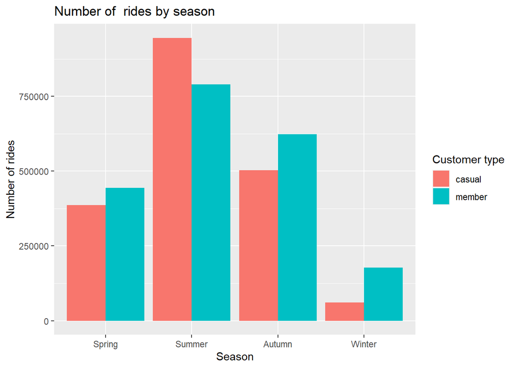

```r
Data %>% group_by(customer_type,season) %>%summarise(total = n())%>% arrange(customer_type,season) %>% ggplot() + geom_col(mapping = aes(x=season,y=total,fill = customer_type),position = "dodge") + labs(x = "Season", y = "Number of rides",fill="Customer type",title = "Number of  rides by season")
```

The above visual shows that ,the summer season bring more riders in total but casual riders usage is nearly nonexistent in the winter season, There are multiple factors which contribute to this result but member riders still use the service at a good rate in all seasons

#### Number of rides by customer type and month

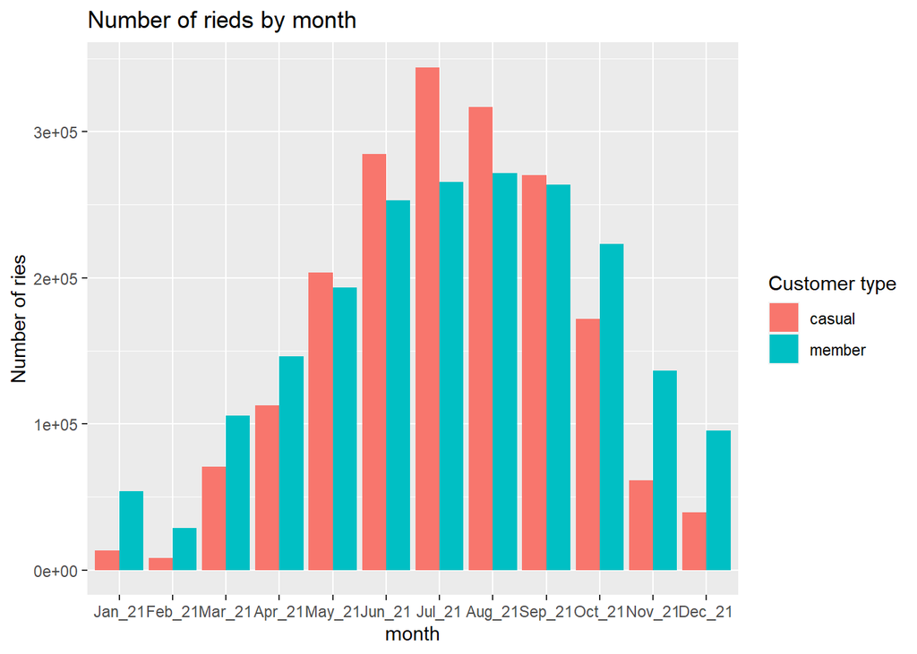

```r
Data %>% group_by(customer_type,month) %>%summarise(total = n())%>% arrange(customer_type,month) %>% ggplot() + geom_col(mapping = aes(x=month,y=total,fill = customer_type),position = "dodge") + labs(x = "month", y = "Number of ries",fill="Customer type",title = "Number of rieds by month")
```

The above visual shows that ,the summer months bring more riders in total but casual rider usage is nearly nonexistent in the winter months. There are multiple factors which contribute to this result but annual members still use the service at a good rate in those months

#### Number of rides by customer type and weekday

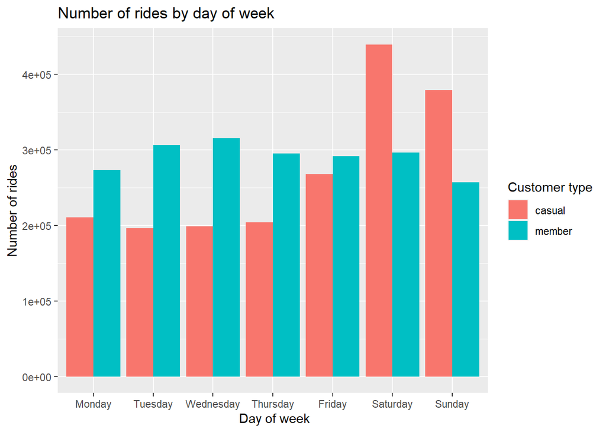

```r
Data %>% group_by(customer_type,day_of_week) %>%summarise(total = n())%>% arrange(customer_type,day_of_week) %>% ggplot() + geom_col(mapping = aes(x=day_of_week,y=total,fill = customer_type),position = "dodge") + labs(x = " Day of week", y = "Number of rides",fill="Customer type",title = "Number of rides by day of week")
```

#### Avarage ride length by customer type and weekday

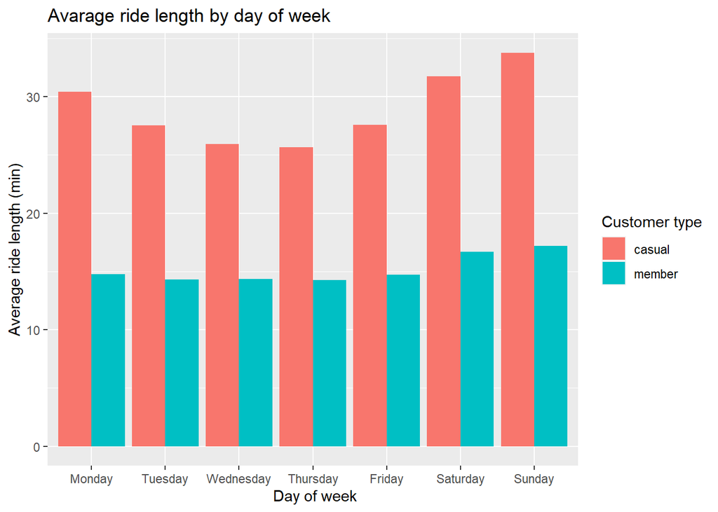

```r
Data %>% group_by(customer_type,day_of_week) %>%summarise(average_ridelength = mean(ride_length))%>% arrange(customer_type,day_of_week) %>% ggplot() + geom_col(mapping = aes(x=day_of_week,y=average_ridelength,fill = customer_type),position = "dodge") + labs(x = " Day of week", y = "Average ride length (min)",fill="Customer type",title = "Avarage ride length by day of week")
```

The above visual shows that, the casual riders is considerably longer than those of members and peak on Saturday and Sunday. Annual members bike a near constant length regardless of day of week.

#### Number of rides by customer type and type of day

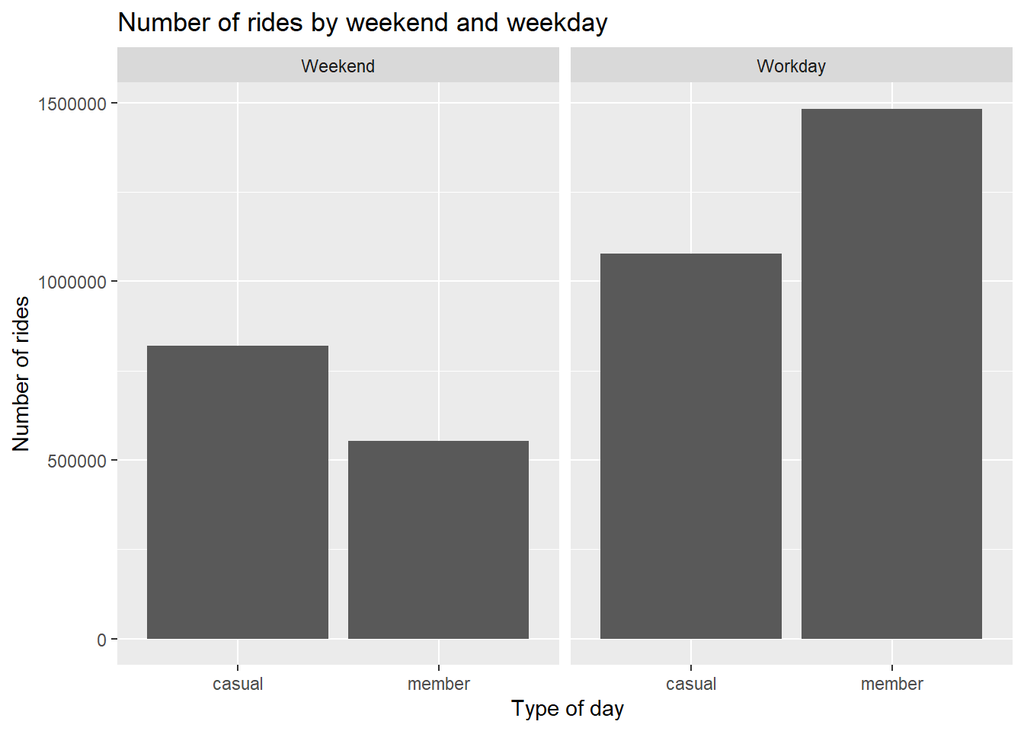

```r
Data %>% group_by(customer_type,type_of_day) %>%summarise(total = n())%>% arrange(customer_type,type_of_day) %>% ggplot() + geom_col(mapping = aes(x=customer_type,y=total),position = "dodge") + labs(x = " Type of day", y = "Number of rides",title = "Number of rides by weekend and weekday") + facet_wrap(~type_of_day)
```

#### Number of rides by customer type and time

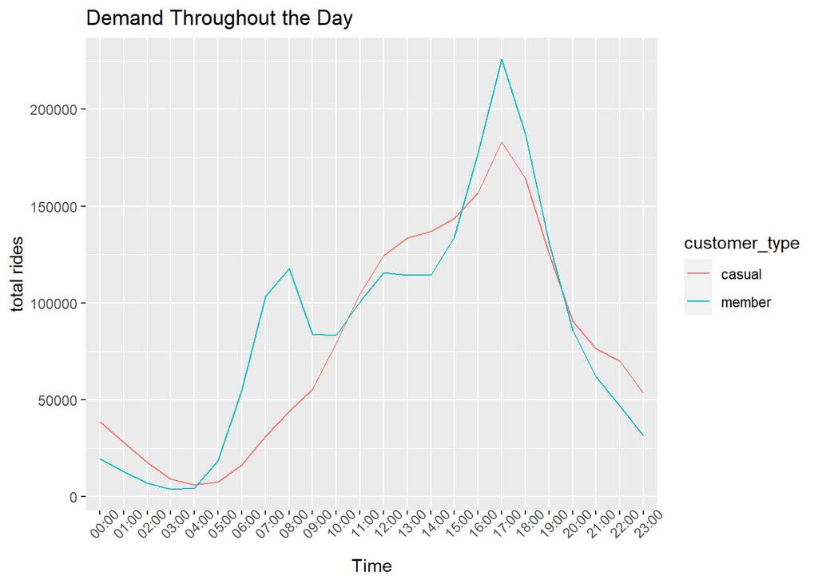

```r
Data %>% group_by(customer_type,time) %>%summarise(total_rids = n()) %>% ggplot() + geom_line(mapping = aes(x=time,y=total_rids,color = customer_type, group = customer_type)) + labs(x = "Time", y = "total rides",fill="Customer type",title = "Demand Throughout the Day")+theme(axis.text.x = element_text(angle = 45))
```

#### Number of rides by customer type and bike type

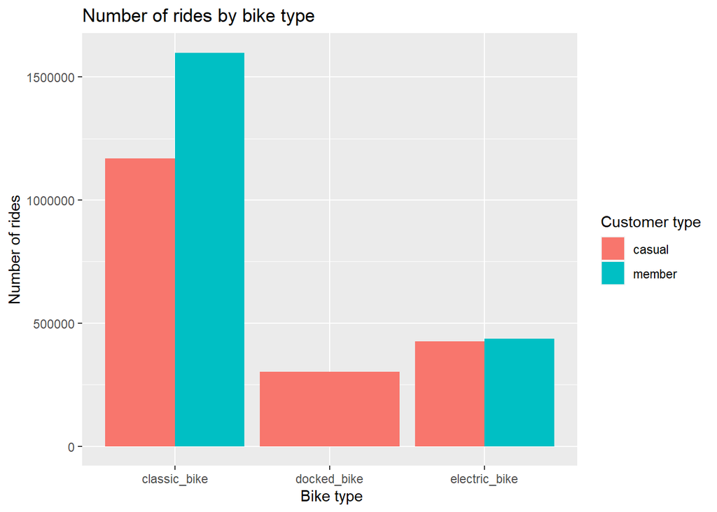

```r
Data %>% group_by(customer_type,bike_type) %>%summarise(total = n())%>% arrange(customer_type,bike_type) %>% ggplot() + geom_col(mapping = aes(x=bike_type,y=total,fill = customer_type),position = "dodge") + labs(x = " Bike type", y = "Number of rides",fill="Customer type",title = "Number of rides by bike type")
```

The above visual shows that, the members use classic bikes much more than casual members. The electric bike use is nearly identical but casual riders are more willing to use docked bikes.

#### Number of rides of member customers by station with most number of rides (Top10)

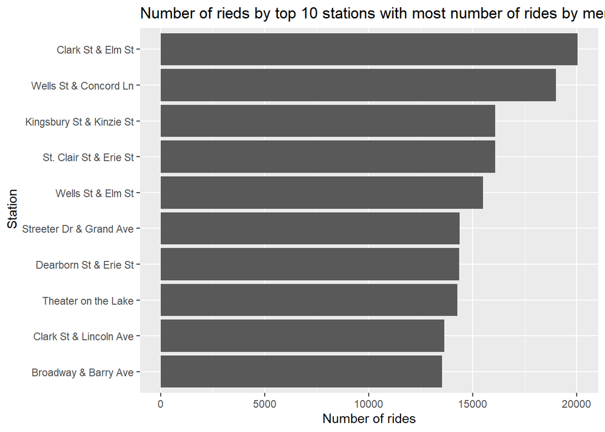

```r
Data %>% filter(customer_type == "member")%>%group_by(start_station_name) %>%summarise(total = n())%>% top_n(10) %>%arrange(total)%>%ggplot() + geom_col(mapping = aes(x=reorder(start_station_name,total),y=total),position = "dodge") + labs(x = " Station", y = "Number of rides",title = "Number of rieds by top 10 stations with most number of rides by member")+ coord_flip()
```

the above visual shows, the top 10 start stations with most number of rides by members, based on my research these are resident areas

#### Number of rides of casual customers by station with most number of rides (Top10)

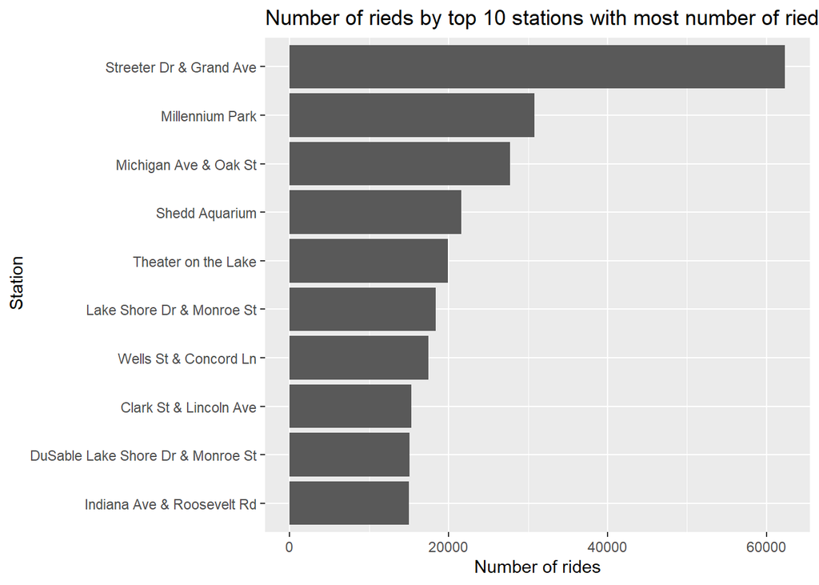

```r
Data %>% filter(customer_type == "casual")%>%group_by(start_station_name) %>%summarise(total = n())%>% top_n(10) %>%arrange(total)%>%ggplot() + geom_col(mapping = aes(x=reorder(start_station_name,total),y=total),position = "dodge") + labs(x = " Station", y = "Number of rides",title = "Number of rieds by top 10 stations with most number of rieds by causal")+ coord_flip()
```

the above visual shows, the top 10 start stations with most number of rides by casual, based on my research these are city center and cultural areas.

#### Number of rides of member customers by route with most number of rides (Top10)

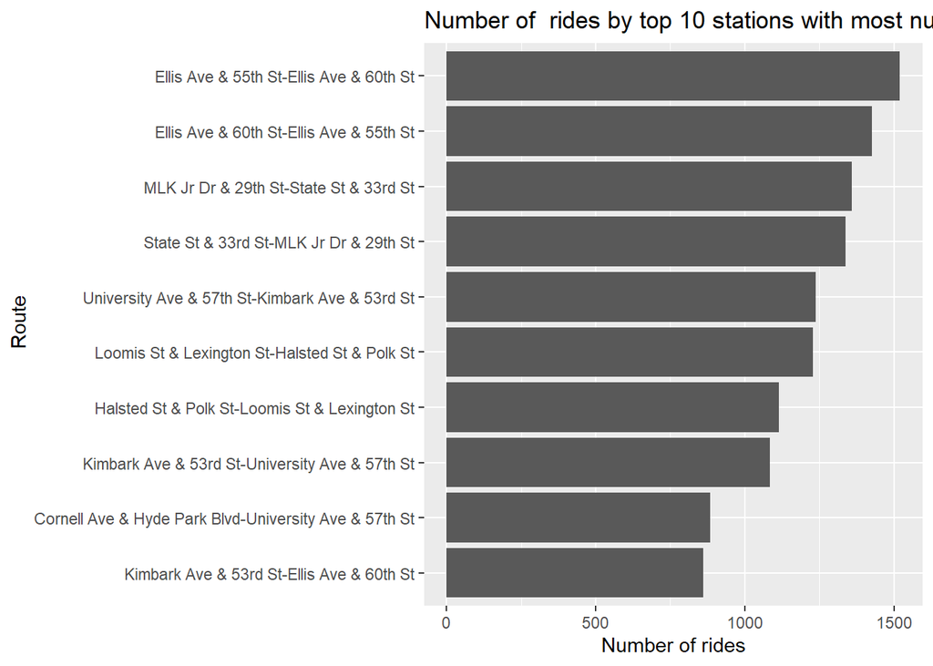

```r
Data %>% filter(customer_type == "member")%>%group_by(route) %>%summarise(total = n())%>% top_n(10) %>%arrange(total)%>%ggplot() + geom_col(mapping = aes(x=reorder(route,total),y=total),position = "dodge") + labs(x = " Route", y = "Number of rides",title = "Number of  rides by top 10 stations with most number rieds by member ")+ coord_flip()
```

the above visual shows, the top 10 routes with most number of rides by members.

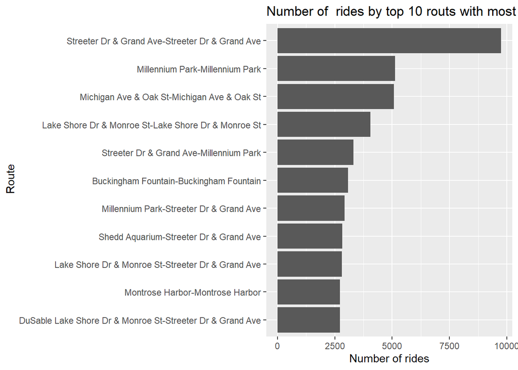

```r
Data %>% filter(customer_type == "casual")%>%group_by(route) %>%summarise(total = n())%>% top_n(10) %>%arrange(total)%>%ggplot() + geom_col(mapping = aes(x=reorder(route,total),y=total),position = "dodge") + labs(x = " Route", y = "Number of rides",title = "Number of  rides by top 10 routs with most number of rides")+ coord_flip()
```

the above visual shows, the top 10 routs with most number of rides by casual.

## Phase 5 : Share

Now we’re ready to share our findings with team.

### Key findings

●Casual riders mostly use bike-sharing for leisure and tourism purposes and are highly active on weekends

●Members use bike-sharing to commute to work during the week and are more active on weekdays rather than weekends.

●Member riders mainly use the bikes for their commutes as their usage peaks on weekdays during rush hour

●Casual riders use the bikes more for leisure based on the peak usage in summer months and weekends

●Casual riders do not use the service during the winter months as much as annual members

●Annual members mainly use classic bikes and rarely use docked bikes but casual riders are more open to riding all kinds of bikes specially for ducked bike

## Phase 6 : Act

### Recommendations

1.Based on finding it’s worth considering to offer new types of membership focused on weekend rides

2.As Casual riders use bikes for much longer trips than members, we should offer bonuses for longer rides

3.The campaign should start in spring offering early-bird discounts for these new types of memberships and continue during the Summer peak

4.We should increase the number of ducked bikes in stations